# Star annd planet formation - Problem set 1

Simon Karlsson

E-mail: skrotupplag@hotmail.com

Date: 140508

```python
from __future__ import division
from astropy import constants as con
import scipy as sp
import matplotlib.pyplot as plt
from scipy.integrate import odeint
import numpy as np
from astropy import units as u
from IPython.display import Image
```

## 1. Observational characteristics of interstellar clouds

**Q:**

Describe briefly how to empirically determine...

- (a) ...the distance $D$ to a cloud.
- (b) ...the mass $M$ of a cloud.
- (c) ...the extinction $A_V$ of a cloud.
- (d) ...the pressure $P$ of a cloud.
- (e) ...the age $t$ of a cloud.

**A:**

a)

One way to measure the distance to clouds is by *spectroscopic parallax*. Spectroscopic parallax works by first taking a spectra of a star and determine its *spectral class*. Once we know this we can place the star in an HR-diagram and read of an expected absolute magnitude $M$ for such a star. Then we use photometry to measure the stars apparent magnitude $m$ and calculate the distance to the star from the *distance modulus*

$$ m-M = 5 \log(\frac{d}{10}) +A $$

with the assumption that we know the extinction $A$. Here we of course assume that the stars in question are located in the cloud complex. This technique is not very precise, but the accuracy can be increased by measuring many stars in the cloud.

b)

In the context of giant molecular clouds we can picture the structure of these clouds as consisting of individual dark core clumps moving in random directions as a consequence of the gravitational field by the whole structure. The *virial velocity*---the velocity of a gas parcel that traverses the cloud in the free fall time $\tau_{ff}$---can then be used to calculate the mass of the whole structure. It is defined as

$$ V_{vir} = \left(\frac{GM}{R}\right)^{1/2} $$

where we approximate the spacial structure as a sphere with radius $R$. It can be shown that the velocity dispersion $\Delta V$ in the cloud is roughly equal to $V_{vir}$. If we measure the velocity dispersion from spectral line broadening (typically CO-lines) and combine it with estimates of $R$ we can then calculate the mass $M$ of the cloud.

Another way to estimate the mass of clouds is by estimating the number densities in clouds. It can be done from the empirical relationships

$$ N_{CO}^{13} = 2.5 \cdot 10^{15} A_V $$

$$ N_H = 7.5 \cdot 10^5 N_{CO} $$

where $N_{CO}^{13}$ is the column density of $^{13}C ^{16}O$ and $A_V$ is the extinction in the V-band. By estimating $A_V$ we can then estimate the column density of neutral hydrogen $N_H$. Once we have the column density we can derive the number density from spacial information of the cloud. The estimation of $A_V$ is explained in c).

c)

To determine the extinction of a cloud we imagine a cloud contained in a solid angle $\Omega_c$ and between the two distances $r_1$ and $r_2$ as seen in the figure below. If the cloud is not too opaque we may estimate $A_V$ from the obscuration of background stars. If the cloud itself is the only source of extinction, the stars that are at a distance $r > r_2$ will have a higher magnitude by $A_V$. From the distance modulus the distance to the stars increases with $m_V$ as

$$ \Delta \log r = 0.2 \Delta m_V. $$

However this relation only holds for the unobscured stars in front of the cloud and if we make a plot of the apparent magnitude versus the number of stars, we see a shift from the expected linear curve as can be seen in the plot below. $A_V$ can then be directly determined from such a plot.

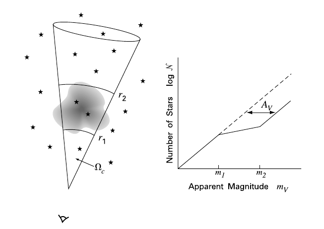

```python
Image('AvEstimate.png')
```

d)

The pressure of a cloud can be estimated from temperature measurements. If we for example assume an equation of state for the cloud as $P = \rho c_S^2$ and $c_S = \sqrt{\mathcal{R} T / \mu}$ where $P$ is the pressure, $c_S$ is the sound speed of the gas, $\rho$ is the density, $\mathcal{R}$ is the gas constant, $\mu$ is the mean molecular weight and $T$ is the temperature, then we can estimate the pressure from the temperature assuming we have knowledge about the density and mean molecular weight. The temperature can for example be estimated from CO-lines.

e)

We can estimate the age of a cloud if we assume that all the stars in in the cloud formed at the same time and from the same cloud. Then they should all have similar properties except from their masses. If they have a range in masses we should see a large spread of stars along the main sequence. As the star ages, the higher mass stars burn out their hydrogen faster than the lower mass stars and we can therefore expect to see the main sequence of stars to become shorter over time. If you can find out exactly what type of star is just leaving the main sequence to become a red giant and you know from stellar models the expected age of such a star, then the age of the cloud should be roughly the same as that star since all stars formed simultaneously.

## 2. Stability of an Isothermal cloud

**Q:**

A spherically symmetric isothermal cloud satisfies the isothermal Lane-Emden equation

$$ \frac{1}{\xi^2} \frac{d}{d\xi} \left(\xi^2 \frac{d \psi}{d\xi} \right) = \exp (-\psi) $$

(equation 9.7 in Stahler & Palla), where

$$ \xi = r \sqrt{\frac{4\pi G \rho_c}{c_s^2}} $$

$\psi = \Phi / c_s^2$ , $c_s = \sqrt{RT /\mu}$ is the sound speed, $\Phi$ is the gravitational potential, $G = 6.67 \cdot 10^{−11}$ m$^3$ kg$^{−1}$ s$^{−2}$ is the gravitational constant, $R = 8.31 \cdot 10^7$ erg g$^{−1}$ K$^{−1}$ is the gas constant, $\mu$ is the mean molecular weight, $T$ is the gas temperature, and $\rho_c$ is the central density.

Let $\mu = 2$, $T = 25$ K, $\rho_c = 7.5\cdot 10^{−20}$ g cm$^{−3}$ and assume the equation of state $P = \rho c_s^2$ , where $P$ is the pressure and $\rho$ the density. Assume an external pressure of $P_{\text{ext}} = 8.0 \cdot 10^{−13}$ Pa from the interstellar medium is being applied on the sphere.

(a) What is the sound speed?

(b) What is the mass of the sphere? You may use Figs. 1 & 2 to read out values derived from the solution of the differential equation.

(c) Imagine that the external pressure starts to rise. How high can it rise before the sphere becomes unstable?

(d) Assume instead that the clouds starts to (isothermally) cool. How much can it cool before the sphere becomes unstable?

(e) Solve the isothermal Lane-Emden equation numerically, and reproduce Figs. 1 & 2. To solve the differential equation, show that it is equivalent to solve the non-linear system of ordinary first-order differential equations

$$ y'_0 = y_1 $$

$$ y'_1 = \exp(-y_0) - \frac{2}{\xi} y_1 $$

where the prime signifies derivation with respect to $\xi$ , $y_0 = \psi $, and the initial condition is $y_0 = y_1 = 0$. This may then be solved by e.g. Euler’s method, i.e. start from the initial condition, and iteratively compute

$$ y_i(\xi_{n+1}) = y_i(\xi_n) + y'_i\left[\xi_n , y_1(\xi_n), y_2(\xi_n)\right]\Delta \xi_n $$

where $\Delta \xi_n = \xi_{n+1} − \xi_n$ is the length step and $i \in \lbrace 1, 2\rbrace$. Check that the solution converges as $\Delta \xi \rightarrow 0$ $(\forall n)$. You are of course welcome to solve the differential equation by other means (e.g. by using Mathematica, Maple, or MATLAB).

**A:**

a)

The sound speed is defined as $c_s = \sqrt{RT /\mu}$. I make a small calculation below with given constants

```python
mu = 2
T = 25*u.Kelvin
R = 8.31*10**7 *(u.erg*u.gram**-1 *u.Kelvin**-1)

cs = np.sqrt(R*T/mu)
cs
```

$32229.6 \; \mathrm{\frac{erg^{1/2}}{g^{1/2}}}$

Lets turn it into SI units

```python
cs.decompose()
```

$322.296 \; \mathrm{\frac{m}{s}}$

Before moving on to the next questions i choose to solve the differential equation right away; reproducing plots 1 and 2.

e) and b)

To solve the differential equation I use a ODE solver in scipy.

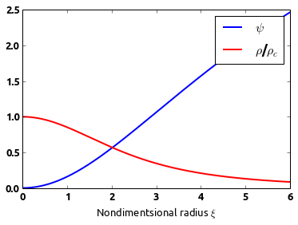

```python
%matplotlib inline
from __future__ import division
from scipy import integrate

P_ext = 8*10**-12		# -13 in Pa, -12 in cgs units (bary 'barr-ee')
rho_ext = P_ext/(cs.value**2)		#7.7*10^-22 g cm^-3
rho_c = 7.5*10**-20
rho_ratio = rho_ext/rho_c	#0.1
psi_ext = -sp.log(P_ext/(rho_c*cs.value**2))


def f(y, t):
    y0 = y[0]
    y1 = y[1]

    f0 = y1
    f1 = sp.exp(-y0) - (2/t)*y1
    return [f0, f1]

y_init = [0, 0]         #create a list with initial conditions
t = sp.linspace(0.0001, 6, 5000)         #create a list with equidistant integration "steps" (start,stop, nr of steps)

#Python ODE solver. Takes the function f, inital conditions y_init and steps t as input
solu = sp.integrate.odeint(f, y_init, t)
psi = solu[:,0]          #saves the psi values in list psi
psi_diff = solu[:,1]     #saves the derivative of psi in list psi_diff


rho_frac = sp.exp(-psi)     #calculates the fraction rho/rho_c

xi_ext_index_list = sp.where(rho_frac < rho_ratio)     #selects the indexes from the list of rho/rho_c values that are < rho_ratio
xi_ext_index = xi_ext_index_list[0][0]         #select first element in list.
xi_ext = t[xi_ext_index]         #uses the selected index to pick out the radius where the bonnor-evert sphere ends

# plot the results
font = {'family' : 'ubuntu',
        'size'   : 13}

plt.rc('font', **font)
plt.figure(1)
plt.plot(t, psi, color='blue', linewidth = 2, label='$\psi$')
plt.plot(t, rho_frac, color='red', linewidth = 2,label='$\\rho$/$\\rho_c$')
plt.xlabel('Nondimentsional radius $\\xi$')
plt.legend()
plt.show()
```

This reproduces plot one perfectly.

To produce the Second plot I create a for-loop that loops over a list with different external pressures from $10^{-10}$ to $10^{-15}$ Ba (barye). In each loop the differential equation is solved and the dimensionless mass $m$ is calculated from

$$ m \equiv \frac{M}{\left( \frac{c_S^2}{\rho_{ext}^{1/3} G} \right)^{3/2} } = \sqrt{\frac{\rho_{\text{ext}}}{4\pi \rho_c}} \left( \xi^2 \frac{d\psi}{d\xi}\right) \vert_{\xi = \xi-ext}. $$

which can be found from integrating shells as

$$ M = \int \rho 4\pi r^2 dr = 4\pi \rho_c \left( \frac{c_S^2}{4\pi G \rho_c} \right)^{3/2} \left[\xi^2 \frac{d\psi}{d\xi} \right]_0^{\xi_{ext}} $$

but before I do this I calculate the mass of the cloud as

```python
m_calc = np.sqrt(rho_ext/(4*np.pi*rho_c))*((xi_ext**2)*psi_diff[xi_ext_index])
```

```python
M = m_calc*(cs.value**2 /(rho_ext**(1/3)*con.G.cgs.value))
```

```python
print M
```

```
9.19432001849e+22
```

Now I iterate over different pressures with the code below

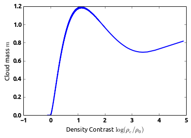

```python
m = np.array([])         #create an empty array for storing dimensionless mass values
rho_ext_frac = np.array([])         #create an empty array for storing values of the fraction rho_c/rho_ext
PextList = np.linspace(10**-10,10**-15,10000)         #make a list of external pressures

##########################
#
# this for-loop loopes over the list of external pressures creating a
# different endpoint on the bonnor-ebert sphere in each loop.
#
#########################
for P_ext in PextList:
    rho_ext = P_ext/(cs.value**2)
    rho_c = 7.5*10**-20
    rho_ratio = rho_ext/rho_c	#0.1
    psi_ext = -sp.log(P_ext/(rho_c*cs.value**2))

    def f(y, t):
        y0 = y[0]
        y1 = y[1]

        f0 = y1
        f1 = sp.exp(-y0) - (2/t)*y1
        return [f0, f1]



    y_init = [0, 0]         #create a list with initial conditions
    t = sp.linspace(0.0001, 500, 10000)         #create a list with equidistant integration "steps" (start,stop, nr of steps)

    #Python ODE solver. Takes the function f, inital conditions y_init and steps t as input
    solu = sp.integrate.odeint(f, y_init, t)
    psi = solu[:,0]          #saves the psi values in list psi
    psi_diff = solu[:,1]     #saves the derivative of psi in list psi_diff


    rho_frac = sp.exp(-psi)     #calculates the fraction rho/rho_c

    xi_ext_index_1ist = sp.where(rho_frac < rho_ratio)     #selects the indexes from the list of rho/rho_c values that are < rho_ratio
    xi_ext_index = xi_ext_index_1ist[0][0]         #select first element in list.
    xi_ext = t[xi_ext_index]         #uses the selected index to pick out the radius where the bonnor-evert sphere ends

    m_calc = np.sqrt(rho_ext/(4*np.pi*rho_c))*((xi_ext**2)*psi_diff[xi_ext_index])     #calculates the dimensionless mass
    rho_ext_frac = np.append(rho_ext_frac, np.log10((rho_c/rho_ext)))     #calculates rho_c/rho_ext and appends it to an array
    m = np.append(m,m_calc)     #append calculated dimensionless mass to array



# plot the results
font = {'family' : 'ubuntu',
        'weight' : 'bold',
        'size'   : 13}

plt.rc('font', **font)
plt.figure(2)
plt.plot(rho_ext_frac, m, color='blue', linewidth = 2)
plt.xlabel('Density Contrast $\log(\\rho_c/\\rho_0)$')
plt.ylabel('Cloud mass $m$')
plt.show()
```

This reproduces the second plot.

c)

As we increase the external pressure this causes a compression of the cloud that in turn causes an increase in the internal pressure. This pressure then makes the cloud expand and we have a kind of oscillatory motion of the cloud. However after a certain increase, the cloud has a harder time expanding and to the right of the cloud mass maximum of $\approx 1.2$ gravity is dominating and the cloud no longer is stable. We therefore have a maximum pressure where we have a maximum cloud mass $m$.

To find the maximum I simply selects the maximum value of the curve and selects the corresponding external pressure with the following code.

```python
mMax = np.max(m)  #selects the maximum value in the list of saved masses
index = sp.where(m == mMax) #selects the index for the maximum mass
pressureLimit = PextList[index]
```

```python
print pressureLimit[0]
```

```
5.76151845185e-12
```

We therefore have the limit where the cloud becomes gravitationally unstabe at roughly $P_{ext} = 5.762 \cdot 10^{-13}$ Pa

d)

To investigate how much the cloud can cool before it becomes unstable i solve it in a similar way as in b) but instead of iterating over different pressures I iterate over different temperatures.

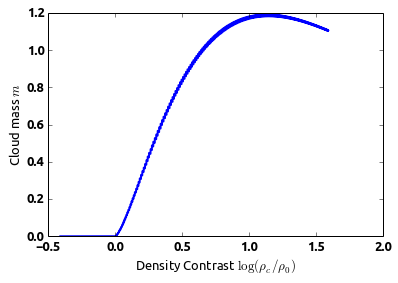

```python
m = np.array([])         #create an empty array for storing dimensionless mass values
rho_ext_frac = np.array([])         #create an empty array for storing values of the fraction rho_c/rho_ext
tempList = np.linspace(1,100,10000)         #make a list of temperatures

##########################
#
# this for-loop loopes over the list of temperatures creating a
# different endpoint on the bonnor-ebert sphere in each loop.
#
#########################
for T in tempList:
    P_ext = 8*10**-12
    cs = np.sqrt(R*T/mu)
    rho_ext = P_ext/(cs.value**2)		#7.7*10^-22 g cm^-3
    rho_c = 7.5*10**-20
    rho_ratio = rho_ext/rho_c	#0.1
    psi_ext = -sp.log(P_ext/(rho_c*cs.value**2))


    def f(y, t):
        y0 = y[0]
        y1 = y[1]

        f0 = y1
        f1 = sp.exp(-y0) - (2/t)*y1
        return [f0, f1]



    y_init = [0, 0]         #create a list with initial conditions
    t = sp.linspace(0.0001, 500, 10000)         #create a list with equidistant integration "steps" (start,stop, nr of steps)

    #Python ODE solver. Takes the function f, inital conditions y_init and steps t as input
    solu = sp.integrate.odeint(f, y_init, t)
    psi = solu[:,0]          #saves the psi values in list psi
    psi_diff = solu[:,1]     #saves the derivative of psi in list psi_diff


    rho_frac = sp.exp(-psi)     #calculates the fraction rho/rho_c

    xi_ext_index_1ist = sp.where(rho_frac < rho_ratio)     #selects the indexes from the list of rho/rho_c values that are < rho_ratio
    xi_ext_index = xi_ext_index_1ist[0][0]         #select first element in list.
    xi_ext = t[xi_ext_index]         #uses the selected index to pick out the radius where the bonnor-evert sphere ends

    m_calc = np.sqrt(rho_ext/(4*np.pi*rho_c))*((xi_ext**2)*psi_diff[xi_ext_index])     #calculates the dimensionless mass
    rho_ext_frac = np.append(rho_ext_frac, np.log10((rho_c/rho_ext)))     #calculates rho_c/rho_ext and appends it to an array
    m = np.append(m,m_calc)     #append calculated dimensionless mass to array


# plot the results
font = {'family' : 'ubuntu',
        'weight' : 'bold',
        'size'   : 13}

plt.rc('font', **font)
plt.figure(2)
plt.plot(rho_ext_frac, m, color='blue', linewidth = 2)
plt.xlabel('Density Contrast $\log(\\rho_c/\\rho_0)$')
plt.ylabel('Cloud mass $m$')
plt.show()
```

Now I again select the maximum value

```python
mMax = np.max(m)  #selects the maximum value in the list of saved masses
index = sp.where(m == mMax) #selects the index for the maximum mass
tempLimit = tempList[index]
```

```python
print tempLimit[0]
```

```
35.3762376238
```

## 3. Free-fall collapse of a cloud

**Q:**

The collapse of a Bonnor-Ebert sphere gives rise to a system of differential equations that have to be solved numerically. To get a rough idea of how a cloud behaves under collapse, let us study an even simpler case: a homogeneous sphere of gas without pressure, with gravitation being the only relevant force. The equation of motion can then be written

$$ \ddot{r} = -\frac{G M_r}{r^2} $$

where $r$ is the radius, $M_r$ is the mass interior to $r$, and $G$ is the gravitational constant (as above).

(a) Let $r(t=0) = r_0$ and $\dot{r}(t=0) = 0$, and show that

$$ \frac{\dot{r}}{r_0} = -\sqrt{\frac{2 G M_r}{r^3_0} \left(\frac{r_0}{r} -1 \right)} $$

(b) Introduce

$$ \cos^2(\xi) = \frac{r}{r_0} $$

and show that

$$ \xi +\frac{1}{2}\sin(2\xi) = t\sqrt{\frac{2 G M_r}{r^3_0}} $$

(c) How long does it take a shell to free-fall to the origin? Express the time in the initial density $ρ_0$.

(d) If the uniform sphere had the density $ρ_0$ = $ρ_c$ of Problem 2, what would be the total time for the free fall to the origin?

(e) A wind can sometimes be modelled as antigravity working on gas. The relevant equation of motion would then be

$$ \ddot{r} = (\beta -1) \frac{G M_r}{r^2} $$

where $\beta > 1$. What are the equations in this case, corresponding to equations 2–4?

**A:**

a)

One way to show this is to look at a unit mass $m$ at the edge of the sphere and sometime later as it falls in. For conservation of energy to hold the total energy should then be the same before and after. In other words the sum of potential and kinetic energy of the unit mass before and after should be the same. From this condition I derive the relation by hand below below:

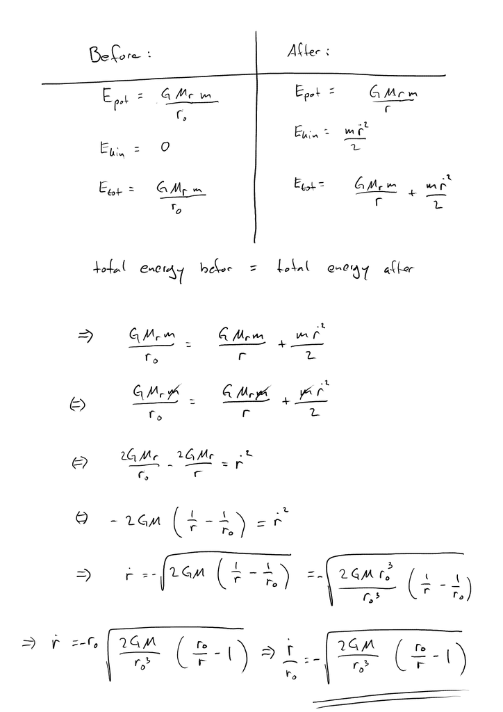

```python
Image('freefall.png')
```

b)

I have no solution for this!

c)

The virial theorem states that

$$ \frac{1}{2}\frac{\delta^2 I}{\delta t^2} = 2T + 2U +W +M $$

where $I$ is the moment of inertia, $T$ is the total kinetic energy, $U$ is the total thermal energy, $W$ is the gravitational energy and $M$ is the magnetic energy. To calculate the free fall time we assume that $W$ dominates and we only have

$$ \frac{1}{2}\frac{\delta^2 I}{\delta t^2} = W. $$

If $W \approx -\frac{G M^2}{R}$ and $I \approx M R^2$ where $R$ is the radius of the cloud, then we have that

$$ \frac{1}{2}\frac{\delta^2 (M R^2)}{\delta t^2} = -\frac{GM^2}{R} \Rightarrow \frac{\delta^2 (R^2)}{\delta t^2} = -\frac{2G M}{R}. $$

If we now a make the approximation (which I can not justify)

$$ \frac{\delta^2 (R^2)}{\delta t^2} \approx \frac{R^2}{\tau^2_{ff}} $$

we have that

$$ \tau_{ff} = \sqrt{\frac{R^3}{2G M}}. $$

d)

If we put in $\rho_0 = \rho_c = 7.5 \cdot 10^{-20}$ and calculate $\tau_{ff}$ we get

```python
tauff = np.sqrt(1/(2*1.25*rho_c*con.G.cgs.value*np.pi))
```

```python
print tauff
```

```
5.0435523424e+12
```

This is in seconds and I want the answer in years sp I divide by the number of seconds in a year

```python
print tauff/(60*60*24*365)
```

```
159929.995637
```

We then get that the free fall time is roughly 159930 years.

e)

I show this in the same way as in a):

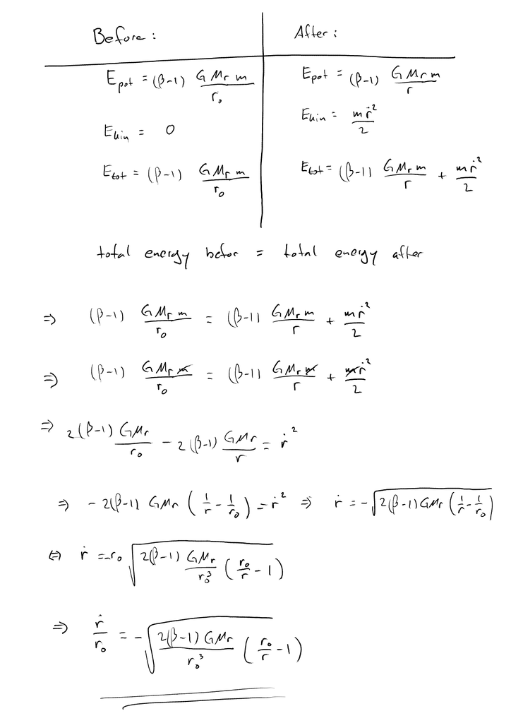

```python
Image('freefallWind.png')
```